# GG Plot 111 Report

## Combining plots using patchwork package.

Patchwork allows you to combine or merge two or more plots in one plot. It is very useful especially if you are working with multiply data sets. It works almost similar to facet_wrap function but patchwork combines plots using different data sets, with facet wrap its only one data set showing different plots. Patchwork use the symbol + to combine data.

option 1

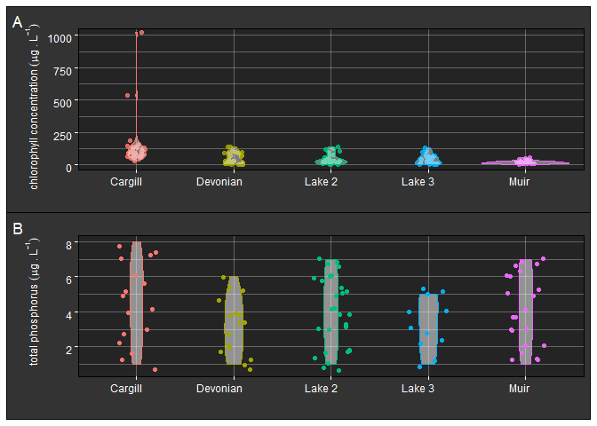

```r
final_plot_1 <- chlorophyll_data + phosphorus_plot1 + plot_layout(nrow = 2, widths = c(3.2)) +     ## using patchwork to + to combine data
                                        plot_annotation(tag_level = c("A", "B", size = 4)) + ## tagging our plots
                                        theme_gerry() +
                                        theme(legend.position = "none")


final_plot_1
```

option 2

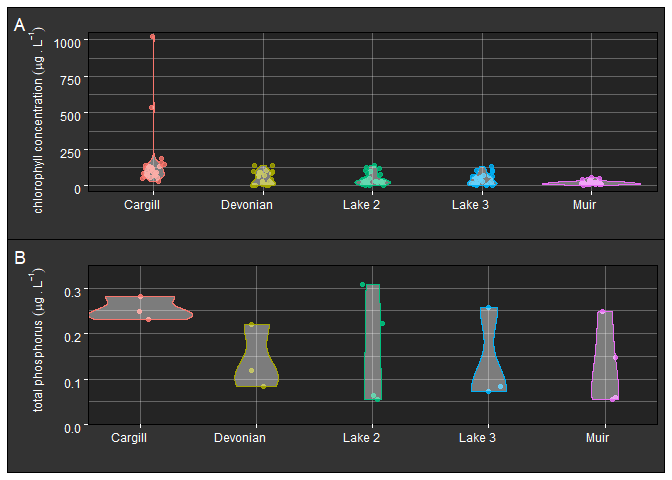

```r
final_plot_2 <- chlorophyll_data + phosphorus_data_2 + plot_layout(nrow = 2, widths = c(3.2)) +     ## using patchwork to + to combine data
                                        plot_annotation(tag_level = c("A", "B", size = 4)) + ## tagging our plots

                                        theme_gerry() +
                                        theme(legend.position = "none")


final_plot_2
```

Saving plots as pdf

```r
ggsave(here("figures", "final_plot_1.pdf"), final_plot_1, width = 190, height = 120, units = "mm")

ggsave(here("figures", "final_plot_2.pdf"), final_plot_1, width = 190, height = 120, units = "mm")
```

Happy coding !!